# UK Carbon Emissions: Segmented Model Application for Carbon Pricing Analysis

Author

Stephan Kadonoff

The Price of Pollution: Analyzing the Efficacy of the United Kingdom’s Carbon Pricing System

## Introduction

Due to climate change, having a system in which we can properly and internally price in the cost of carbon emissions is important not only for preserving the environment, but also to ensure that cost of said pollution is not left as an externalized burden.

The United Kingdom instituted a carbon pricing system in 2013 which set an initial rate of 4.94 British pounds per tonne of CO2 equivalent. While relatively low, the price floor was to serve as the first stage in a progressive system to encourage the transition away from the most polluting energy sources.

To understand the efficacy of this carbon pricing scheme, we will be utilizing a segmented statistical model as an interrupted time series analysis. We will see if there was a change between the post intervention slope at 2013 when the policy was implemented, and the slope before it.

#### Hypothesis

Carbon pricing changed the rate of carbon emission decrease per year faster than without. H0: Slope(s) before and after the breakpoint equal 0 HA: Slope(s) after the breakpoint are less than 0.

$$\begin{align}
Carbon Emissions: H0 : B3 = 0 \\
HA : B3 < 0 \\
\end{align}$$

statistical model notation:

$$Yt = \beta*{0} + \beta{1}\text{t} + \beta*{2}\text{(t - ψ1)} + \beta{3}\text{(t - ψ2)}$$

A segmented model is one characterized by a distinct change in slope or “breakpoint” where-in the model’s line shifts to a new slope value. B0 is, of course, the intercept, B1 is the initial slope of the model along the initial segment of the model. B2 is the point at which the effect is applied to the model’s population, causing the change in slope, with B3 itself showing the new slope after the intervention.

In the context of this study looking at the UK’s carbon pricing model, we say that Y is Carbon Emissions, B1 is the slope of emissions over years, B2 is the change in slope at the first breakpoint when pricing is applied, and B3 is the change at the second breakpoint. The model should, assuming proper fit, produce a single line with 3 distinct slopes.

#### DAG

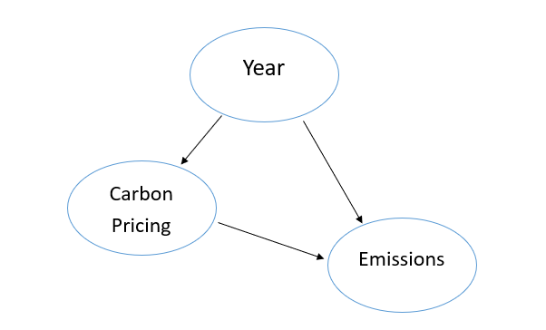

Dag

This dag is a brief overlook at the relationship between the factors which ultimately produce carbon emissions. Specifically, we are looking at three key variables for understanding our model Year, Carbon Pricing, Emissions. The variable Year impacts status of Carbon Pricing, since Year determines if the Carbon Pricing Policy has been implemented yet or not.

Year also impacts Emissions, since the total quantity of Emissions changes by year. Lastly Carbon Pricing also impacts Emissions itself since we would expect a Carbon Pricing policy to impact the choice of fuel source, and thus total emissions.

## Exploratory Work

To begin with, we will add the necessary libraries for this analysis, and then read in the data.

```r
library(tidyverse)
library(here)
library(segmented)
library(knitr)
```

```r
# read in emission data
emission_data <- read_csv(here("data", "GCB2025v15_MtCO2_flat.csv"))
uk_emission_data <- emission_data %>%
  filter(Country == "United Kingdom")%>%
  rename(per_capita = 'Per Capita')
```

Now that we have the data read in, we can begin cleaning and filtering the data for the specific time series we want to evaluate for this study. According to the data, total carbon emissions, as well as per capita emissions, peaked in 1971, so let’s filter to just before that to 1960.

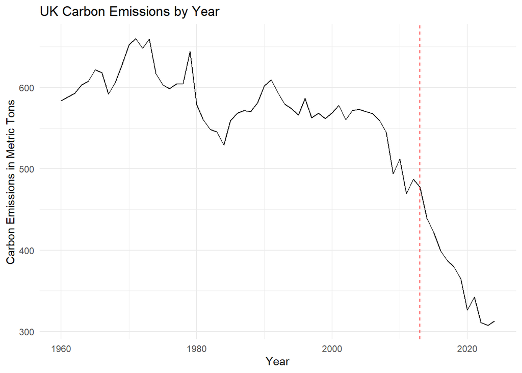

```r
# filter to near peak yearly carbon emissions
uk_emission_scope <- uk_emission_data %>%
  filter(Year >= 1960)

exploratory_plot <- ggplot(uk_emission_scope, aes(x = Year,
                           y = Total)) +
  geom_line() +
  geom_vline(xintercept = 2013,
             color = "red",
             linetype = "dashed") +
  theme_minimal() +
  labs(title = "UK Carbon Emissions by Year",
       x = "Year",
       y = "Carbon Emissions in Metric Tons")
exploratory_plot
```

To understand if this decrease in emissions year over year after the carbon pricing scheme was instituted was steeper than the decrease that is observed before it, we will utilize a segmented model via an interrupted time series analysis of the UK’s carbon emissions.

## Initial Model fitting

### Wrangle Data for Model

To begin with, we will need to do some data wrangling to set-up our data set for modeling.

```r
# mutate emissions variable to format for a Segmented Model
uk_emission_scope <- uk_emission_scope %>%
  mutate(time = Year - min(Year),
         pricing = if_else(Year >= 2013, 1, 0),
         post_pricing = case_when(pricing == 1 ~ row_number() - 54, TRUE~0))
```

Next we will have to create a linear model which we will then use as the basis for the breakpoint/segmented model. Based on the earlier exploratory plot, we can see that there is a drop in carbon emissions starting in the early 2000s. For that reason, we will add a breakpoint at the Year 2002, so that we can better understand if the change in slope we expect to see after 2013 was already appearing in the decade before.

### Create Linear and Segmented Models

```r
# create a linear model of the relationship between emissions and year
lm_emission_model <- lm(Total ~ Year, data = uk_emission_scope)

# create a segmented model based on the linear model
seg_emission_model <- segmented(lm_emission_model,
                                seg.Z = ~Year,
                                psi = list(Year = c(2002, 2013)))
```

We now have our segmented model. The model is already telling us something different then we had initially expected. While we had initially coded in breakpoints at 2002 and 2013, the segmented() function overrode the command and found better breakpoints at 1969, and 2006. Since the model is now placing a breakpoint before the intervention year, we can begin to assume that there in fact is *not* a significant change in carbon emission reduction after the policy intervention.

Lets find the confidence interval(s) of the model.

```r
# Find the CI
confint(seg_emission_model)
```

```
             Est. CI(95%).low CI(95%).up
psi1.Year 1969.20     1963.51    1974.89
psi2.Year 2006.77     2004.91    2008.62
```

### Create Simulated Models

Now, lets try to evaluate the model’s fit by simulating data, according to the model’s assumptions. We will replicate the year range, so 1960 to 2024, and take the coefficients from our segmented model. Lastly, we will also take the breakpoints from our model, rounded down to their closest years 1969 and 2006.

```r
# set the seed for consistency
set.seed(42)

# replicate the year range from our data
simulated_years <- seq(1960, 2024)

# take the coefficient values from the segmented model
b0 <- coef(seg_emission_model)[1]
b1 <- coef(seg_emission_model)[2]
b2 <- coef(seg_emission_model)[3]
b3 <- coef(seg_emission_model)[4]

# breakpoint years
break_1 <- 1969
break_2 <- 2006
# simulate pop

# simulate the emissions across the year range
simulated_emissions <- b0 + b1 * simulated_years +
  b2 * pmax(0, simulated_years - break_1) +
  b3 * pmax(0, simulated_years - break_2)

# since the above simulated emissions is all consistent values along line, add rnorm with a standard deviation equivalent to the original segmented model's standard error

simulated_emissions <- simulated_emissions + rnorm(length(simulated_emissions), sd = 22)


# create a tibble of simulated data, joining the simulated years and simulated emissions
simulated_data <- tibble(year = simulated_years,
                         total = simulated_emissions)
```

To create a simulated dataset of emissions, we utilized the above listed steps, but we also had to add in a degree of uncertainty and variance. This was done with utilizing the above listed coefficients, but also through then joining the simulated components and then joining them via the `tibble()` function.

Now that we have a simulated data set and model, lets see if we can replicate the results from our original segmented model.

```r
# created a simulated lm model
simulated_lm_model <- lm(total ~ year, data = simulated_data)

# fit the simulated lm model to a segmented model
simulated_seg_model <- segmented(simulated_lm_model,
                                 seg.Z = ~year,
                                 psi = list(year = c(break_1, break_2)))

# check the summary and confidence interval outputs of the simulated segmented model

summary(simulated_seg_model)
```

```
    ***Regression Model with Segmented Relationship(s)***

Call:
segmented.lm(obj = simulated_lm_model, seg.Z = ~year, psi = list(year = c(break_1,
    break_2)))

Estimated Break-Point(s):
               Est. St.Err
psi1.year 1968.000  3.811
psi2.year 2007.114  1.092

Coefficients of the linear terms:
             Estimate Std. Error t value Pr(>|t|)
(Intercept) -5801.984   7499.283  -0.774    0.442
year            3.266      3.819   0.855    0.396
U1.year        -5.447      3.834  -1.421       NA
U2.year       -13.404      1.271 -10.542       NA

Residual standard error: 24.75 on 59 degrees of freedom
Multiple R-Squared: 0.9398,  Adjusted R-squared: 0.9347

Boot restarting based on 6 samples. Last fit:
Convergence attained in 3 iterations (rel. change 9.1947e-08)
```

```r
confint(simulated_seg_model)
```

```
             Est. CI(95%).low CI(95%).up
psi1.year 1968.00     1960.37    1975.63
psi2.year 2007.11     2004.93    2009.30
```

With the simulated model created above, with an initial look at the model’s summary and confidence intervals, lets create a tibble to show that we are recovering the parameters from the simulated data.

```r
# extract the psi values from the simulated model
break_estimate <- summary(simulated_seg_model)$psi

tibble(parameter = c("break_1", "break_2"),
       true = c(break_1, break_2),
       estimated = break_estimate[, "Est."])
```

```
# A tibble: 2 × 3
  parameter  true estimated
  <chr>     <dbl>     <dbl>
1 break_1    1969     1968.
2 break_2    2006     2007.
```

The table above shows that the estimated data and model created an output where the estimated breakpoints are almost identical to the “true” breakpoint years, with the estimated years falling within the CI of the original segmented model.

## Find And Discuss Uncertainty

### Plot The Segmented Model

So far we have completed fitting the model and simulating it. But now we need to understand the uncertainty that exists within the model, and visualize both the model’s estimates and the range of potential values that we may find.

Fortunately, the segmented library package in R has a function `slope()` which will help us find the CIs for the each segment along the plotted line.

```r
# extract the slope of the segmented model
seg_model_slope <- slope(seg_emission_model)

# find the CI's per each segment and create a table
slope_table <- kable(seg_model_slope)

slope_table
```

|  | Est. | St.Err. | t value | CI(95%).l | CI(95%).u |
| --- | --- | --- | --- | --- | --- |
| slope1 | 3.5143 | 2.41660 | 1.4543 | -1.3212 | 8.3499 |
| slope2 | -1.8268 | 0.33797 | -5.4053 | -2.5031 | -1.1505 |
| slope3 | -15.2840 | 0.99719 | -15.3270 | -17.2800 | -13.2890 |

From the data above, we see that the emissions slopes drastically decreased at each breakpoint. As discussed, the model found that the breakpoints were found at 1969 and 2006. The `segmented()` function did not see a distinct enough slope decrease after the 2013 policy intervention to create another breakpoint at that year.

Let’s create a dataframe where we utilize our segmented model to mutate the original emissions dataframe, which we will utilize to create the ribbon of variation along the model’s different segments.

```r
# create a new dataframe with the CIs for Final Mapping
prediction_frame <- uk_emission_scope %>%
  mutate(fit = predict(seg_emission_model),
         se = predict(seg_emission_model, se.fit = TRUE)$se.fit,
         upper = fit + 1.25 * se,
         lower = fit - 1.25 * se)
```

Now, with all these pieces, lets plot the segmented model w/ a ribbon and the original emissions data set.

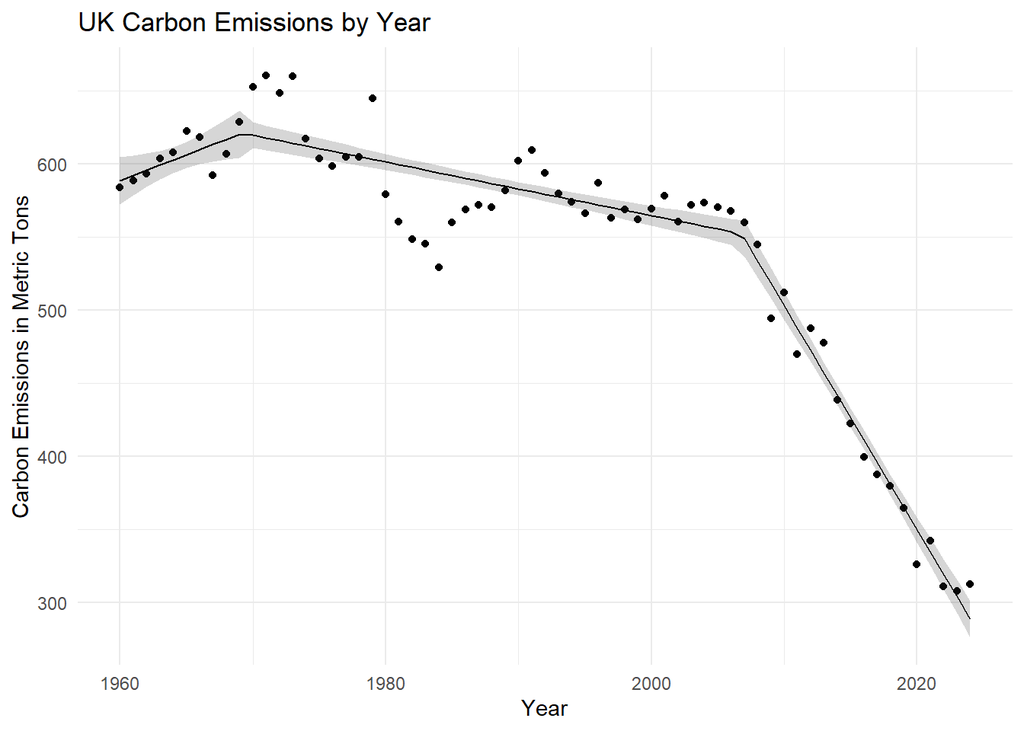

```r
# plot it
confidence_plot <- ggplot() +
  geom_point(data = uk_emission_scope, aes(Year, Total)) +
  geom_ribbon(data = prediction_frame, aes(x = Year, ymin = lower, ymax = upper), alpha = 0.2) +
  geom_line(data = prediction_frame, aes(x = Year, y = fit), color = "black") +
  theme_minimal() +
  labs(title = "UK Carbon Emissions by Year",
       x = "Year",
       y = "Carbon Emissions in Metric Tons")

confidence_plot
```

## Interpretation and Closing Thoughts

To summarize what we’ve accomplished so far, we have taken a dataset containing two key variables, carbon emissions (in metric tons), and the year in which that quantity of carbon was emitted, and created a model, and with that we were able to visualize and understand the most significant changes in the rate of emissions by each year.

The original focus of this analysis was to determine if there was a change in slope after the UK’s carbon pricing policy intervention that led to a steeper decrease in emissions per year then before. Once we began to utilize our data, however, the model did not see a significant enough change in the immediate years before and after the policy intervention to see them as distinct.

If we were to revisit this subject in the future, I think incorporating the exact make-up of each year’s energy sum, as well as the year-to-year UK average costs of each energy source, would help give context to how the energy streams make-up was changing in the lead-up to the policy intervention, and perhaps help account for the model’s choosing of a breakpoint before the intervention year. It would also be interesting to see different trends, such as for countries which have removed carbon pricing schemes (e.g. Australia). All in all, adding more relevant variables and accounting for them within the model would help understand the correlation between carbon emissions and their year.